# HW10

Avinash Ramu

November 28, 2016

## Q21.1

1. If more houses are added per county, the parameter estimates will likely be the same but the finite population standard deviations will go down i.e the uncertainity in the data drops. The superpopulation standard deviation will remain the same since we have the same number of counties. Another way of stating this is that the uncertainity in individual alpha_j and mu_j goes down but the collective uncertainity remains the same.
2. If 4 times as many counties are added, the parameter estimates will likely remain the same but the superpopulation standard deviation will decrease, i.e uncertainity about mu_alpha and sigma_alpha goes down. We are able to better fit the distribution for the alpha_j . This is because we have a larger sample size for alpha_j and we understand this distribution better with more counties. The within county inferences will likely remain the same.
3. If we have 4 times as many houses and 4 times as many counties, both the finite population standard deviation and the superpopulation standard deviations should decrease. This is because we have more samples at both levels. Assuming that our initial samples were a good representation of the underlying population the parameter estimates should not change significantly. Another way of stating this is that the uncertainity of individual alpha_j and mu_j will go down, also uncertainity about the distribution of mu_j s will go down.

## Q21.3

1. Fit a varying intercept varying slope model to the radon data. Get point estimates(median) and 50% intervals for the finite population and superpopulation standard-deviations using this data.

I will use Andy’s code from earlier to setup the model.

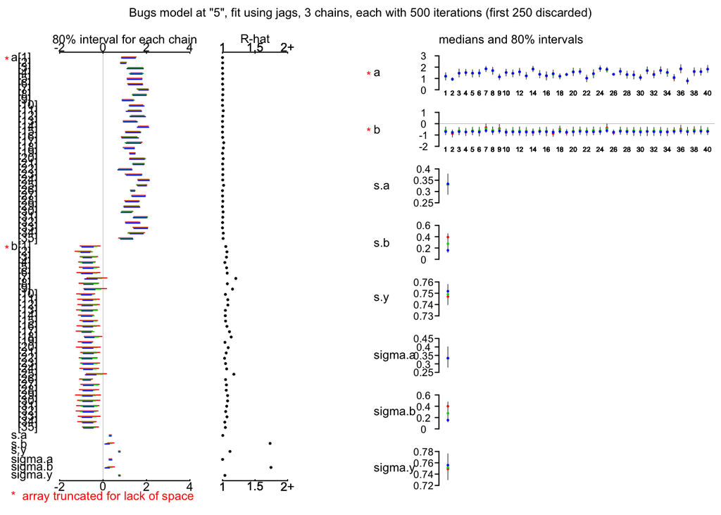

```r
plot(radon.3)
```

```r
attach.jags(radon.3, overwrite = T)

#Toss out the burn-in values
sigma.a <- sigma.a[251:750]
sigma.b <- sigma.b[251:750]
sigma.y <- sigma.y[251:750]
s.a <- s.a[251:750]
s.b <- s.b[251:750]
s.y <- s.y[251:750]

sigma.a_mean <- mean(sigma.a)
sigma.b_mean <- mean(sigma.b)
sigma.y_mean <- mean(sigma.y)
s.a_mean <- mean(s.a)
s.b_mean <- mean(s.b)
s.y_mean <- mean(s.y)

#sigma.a and s.a
print(c(sigma.a_mean, quantile(sigma.a, c(0.25, 0.75))))
```

```
##                 25%       75%
## 0.3376818 0.3082409 0.3643592
```

```r
print(c(s.a_mean, quantile(s.a, c(0.25, 0.75))))
```

```
##                 25%       75%
## 0.3318781 0.3088517 0.3558998
```

```r
#sigma.b and s.b
print(c(sigma.b_mean, quantile(sigma.b, c(0.25, 0.75))))
```

```
##                 25%       75%
## 0.2839738 0.1724487 0.3909267
```

```r
print(c(s.b_mean, quantile(s.b, c(0.25, 0.75))))
```

```
##                 25%       75%
## 0.2790093 0.1704724 0.3769741
```

```r
#sigma.y and s.y
print(c(sigma.y_mean, quantile(sigma.y, c(0.25, 0.75))))
```

```
##                 25%       75%
## 0.7528187 0.7409088 0.7633470
```

```r
print(c(s.y_mean, quantile(s.y, c(0.25, 0.75))))
```

```
##                 25%       75%
## 0.7491576 0.7452301 0.7536315
```

```r
attach.jags(radon.3, overwrite = T)

#Toss out the burn-in values
sigma.a <- sigma.a[251:750]
sigma.b <- sigma.b[251:750]
sigma.y <- sigma.y[251:750]
s.a <- s.a[251:750]
s.b <- s.b[251:750]
s.y <- s.y[251:750]

sigma.a_mean <- mean(sigma.a, na.rm = T)
sigma.b_mean <- mean(sigma.b, na.rm = T)
sigma.y_mean <- mean(sigma.y, na.rm = T)
s.a_mean <- mean(s.a, na.rm = T)
s.b_mean <- mean(s.b, na.rm = T)
s.y_mean <- mean(s.y, na.rm = T)

#sigma.a and s.a
print(c(sigma.a_mean, quantile(sigma.a, c(0.25, 0.75), na.rm = T)))
```

```
##               25%      75%
## 0.324363 0.221660 0.389285
```

```r
print(c(s.a_mean, quantile(s.a, c(0.25, 0.75), na.rm = T)))
```

```
##                 25%       75%
## 0.2687935 0.2186151 0.3106815
```

```r
#sigma.b and s.b
print(c(sigma.b_mean, quantile(sigma.b, c(0.25, 0.75), na.rm = T)))
```

```
##                 25%       75%
## 0.2957847 0.1137677 0.4170219
```

```r
print(c(s.b_mean, quantile(s.b, c(0.25, 0.75), na.rm = T)))
```

```
##                 25%       75%
## 0.2521836 0.1012159 0.3707460
```

```r
#sigma.y and s.y
print(c(sigma.y_mean, quantile(sigma.y, c(0.25, 0.75), na.rm = T)))
```

```
##                 25%       75%
## 0.7452620 0.7245937 0.7669959
```

```r
print(c(s.y_mean, quantile(s.y, c(0.25, 0.75), na.rm = T)))
```

```
##                 25%       75%
## 0.7440589 0.7401155 0.7472681
```

## 21.4

Fit in Bugs a varying-intercept model to the radon data with log uranium as a group-level predictor. You will compare inferences for the superpopulation contrast (that is, the slope for log uranium in the county-level model) and the corresponding finite-population contrast (that is, the coefficient of log uranium for the intercepts for the particular counties in the data). You will need to postprocess the simulations in R in order to get simulations for the finitepopulation contrast.

I used the code from Andy as a reference for the varying intercept model.

Get the contrasts

```r
n.sims <- 750
attach.jags(radon.3, overwrite = T)
mean(g.1)
```

```
## [1] 0.7304816
```

```r
quantile(g.1, c(.025,.975), na.rm = T)
```

```
##      2.5%     97.5%
## 0.5484866 0.8850070
```

```r
finite.slope <- rep (NA, 500)
for (s in 251:n.sims){
  finite.pop <- lm (a[s,] ~ u)
  finite.slope[s] <- coef(finite.pop)["u"]
}
mean(finite.slope, na.rm = T)
```

```
## [1] 0.7298464
```

```r
quantile (finite.slope, c(.025,.975), na.rm = T)
```

```
##      2.5%     97.5%
## 0.5886599 0.8797893
```

The superpopulation and finite-population contrasts are very similar in value.

## Part B - only look at the first three counties

I don’t show the model fitting code, this code is similar to previous downsampling examples in this homework.

Get the contrasts for the model using only three counties. Note - I sampled three random counties instead of picking the first three, the same inferences should hold.

```r
n.sims <- 750
attach.jags(radon.3, overwrite = T)
mean(g.1)
```

```
## [1] 0.5335014
```

```r
quantile(g.1, c(.025,.975), na.rm = T)
```

```
##      2.5%     97.5%
## -70.38818  63.64436
```

```r
finite.slope <- rep (NA, 500)
for (s in 251:n.sims){
  finite.pop <- lm (a[s,] ~ u)
  finite.slope[s] <- coef(finite.pop)["u"]
}
mean(finite.slope, na.rm = T)
```

```
## [1] 0.8965481
```

```r
quantile (finite.slope, c(.025,.975), na.rm = T)
```

```
##      2.5%     97.5%
## 0.3038452 1.4481018
```

The superpopulation and finite-population contrasts are vastly different in this case.

## Q22.1

Take a varying-intercept model from one of the exercises in Part 2 of this book and construct the corresponding ANOVA plot as in Section 22.3.

I will use the varying intercept radon model for this question. Fit the model using the same framework described above.

```r
rm(s.a)
rm(s.y)
attach.jags(radon.3_all_fixed_intercept, overwrite = T)
combined <- data.frame(index = 251:750, s.a = s.a[251:750], s.y = s.y[251:750])
require(reshape2)
```

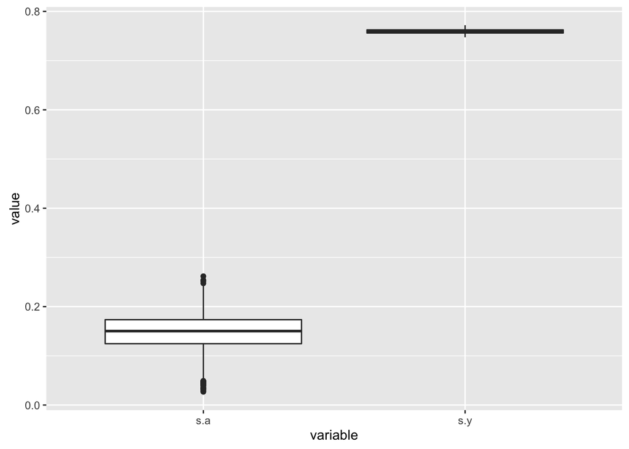

```r
require(ggplot2)
combined_m <- melt(combined, id.vars = c("index"))
ggplot(combined_m) + geom_boxplot(aes(x = variable, y = value))
```